# IODS course project

Sami Itkonen

# Introduction to Open Data Science - Course Project

# About the project

The course is about learning to use R with statistics in, with an emphasis on using it with github. My objective for attending the course is refreshing my knowledge on R and statistics in general. The course has been on my “TODO” plan on PhD studies for a while.

I think the R Data Health book works well for an introduction, although - as I’m not a complete novice. I didn’t read the chapters quite thoroughly - there’s a lot to take in in short time (I missed the exercises in chapter 3, but not chapter 4). Perhaps the book works more as a sample now and later as a reference.

There have been quite a few new things since I last used R, like the tidyverse pipe. I’m glad there is a possibility of using the “language-agnostic standard” of using `=` for assignment instead of (or in addition to) `<-`, which I’ve always found odd. A lot of things are similar to features in pandas in Python data analysis (not surprising, as pandas has taken quite a bit of inspiration from R).

```r
# This is a so-called "R chunk" where you can write R code.

date()
```

```
## [1] "Mon Nov 20 20:38:40 2023"
```

GitHub repository: https://github.com/dustedmtl/IODS-project

# Chapter 2: Regression and model validation

*Data analysis*

```r
date()
```

```
## [1] "Mon Nov 20 20:38:40 2023"
```

The dataset that is read in contains averaged survey scores for three subjects, student attitude, exam points, age, and gender. There are 166 students.

```r
lr2 <- read.table('data/learning2014.csv', sep=',', header = T)
dim(lr2)
```

```
## [1] 166   7
```

```r
summary(lr2)
```

```
##     gender               age           attitude         points
##  Length:166         Min.   :17.00   Min.   :14.00   Min.   : 7.00
##  Class :character   1st Qu.:21.00   1st Qu.:26.00   1st Qu.:19.00
##  Mode  :character   Median :22.00   Median :32.00   Median :23.00
##                     Mean   :25.51   Mean   :31.43   Mean   :22.72
##                     3rd Qu.:27.00   3rd Qu.:37.00   3rd Qu.:27.75
##                     Max.   :55.00   Max.   :50.00   Max.   :33.00
##       deep            surf            stra
##  Min.   :1.583   Min.   :1.583   Min.   :1.250
##  1st Qu.:3.333   1st Qu.:2.417   1st Qu.:2.625
##  Median :3.667   Median :2.833   Median :3.188
##  Mean   :3.680   Mean   :2.787   Mean   :3.121
##  3rd Qu.:4.083   3rd Qu.:3.167   3rd Qu.:3.625
##  Max.   :4.917   Max.   :4.333   Max.   :5.000
```

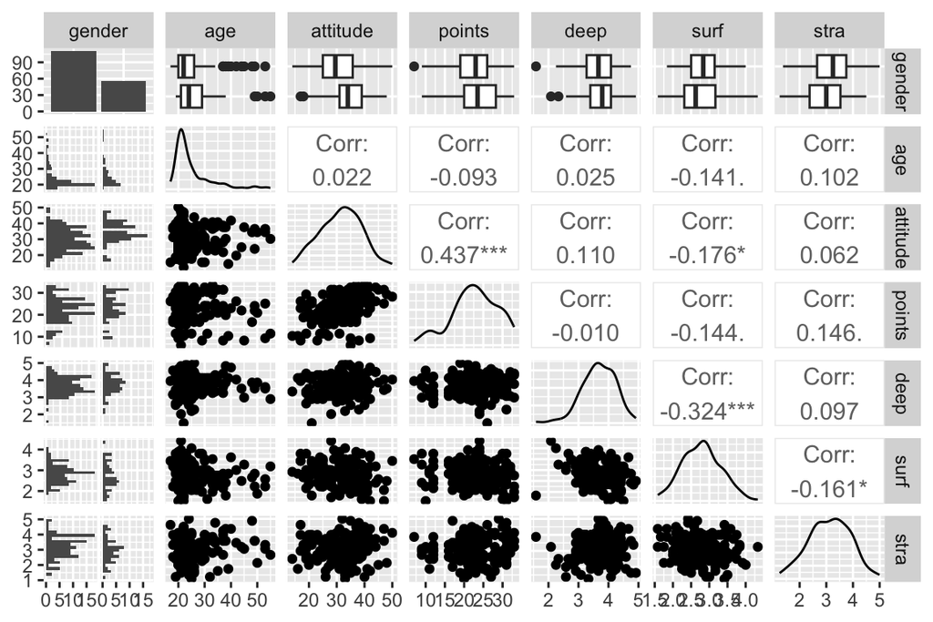

```r
library(ggplot2)
library(GGally)
p <- ggpairs(lr2, mapping = aes(), lower = list(combo = wrap("facethist", bins = 20)))

# draw the plot
p
```

The score variables deep, surf and stra are distributed between 1 and 5.

Correlations in the data:

- points and attitude are strongly correlated
- points and stra are also correlated; likewise points and surf (negative correlation)
- age skews young and it isn’t strongly correlated with anything.

## Linear regression

Linear regression is used to determine relation between a response variable and one of more (if multiple regression) explanatory variables. For a single variable, the equation to solve is:

$Y = \alpha + \beta X + \epsilon$

where all the terms are $N$-dimensional vectors (for $N$ observations). $Y$ is the response variable and $X$ is the explanatory variable. The $\epsilon$ error term is assumed to normally distributed with a mean of 0.

The task is to find such coefficients for $\alpha$ and $\beta$ that minimize the sum $\sum_{i=1}^{N} \epsilon_i^2$. This is called the least squares method.

For multiple linear regression the equation would be similarly $Y = \alpha + X\beta + \epsilon$, where $X$ would be a matrix of dimensions $N * k$ (with $k$ explanatory variables) instead of a $N * 1$-dimensional vector.

Linear regression model for variable points based on three explanatory variables: attitude, stra and surf:

```r
model <- lm(points ~ attitude + stra + surf, data = lr2)

summary(model)
```

```
##
## Call:
## lm(formula = points ~ attitude + stra + surf, data = lr2)
##
## Residuals:
##      Min       1Q   Median       3Q      Max
## -17.1550  -3.4346   0.5156   3.6401  10.8952
##
## Coefficients:
##             Estimate Std. Error t value Pr(>|t|)
## (Intercept) 11.01711    3.68375   2.991  0.00322 **
## attitude     0.33952    0.05741   5.913 1.93e-08 ***
## stra         0.85313    0.54159   1.575  0.11716
## surf        -0.58607    0.80138  -0.731  0.46563
## ---
## Signif. codes:  0 '***' 0.001 '**' 0.01 '*' 0.05 '.' 0.1 ' ' 1
##
## Residual standard error: 5.296 on 162 degrees of freedom
## Multiple R-squared:  0.2074, Adjusted R-squared:  0.1927
## F-statistic: 14.13 on 3 and 162 DF,  p-value: 3.156e-08
```

The test that the fitting is done is omnibus F-test, which tests the hypothesis that coefficients for all three variables are zero. The very low p-value for intercept means that this hypothesis is not likely to be true.

The p-value for attitude (below 0.05) shows that the model fitting is reliable for it.

Multiple R squared value of 0.2074 means that the three variables account for 20 % of variation.

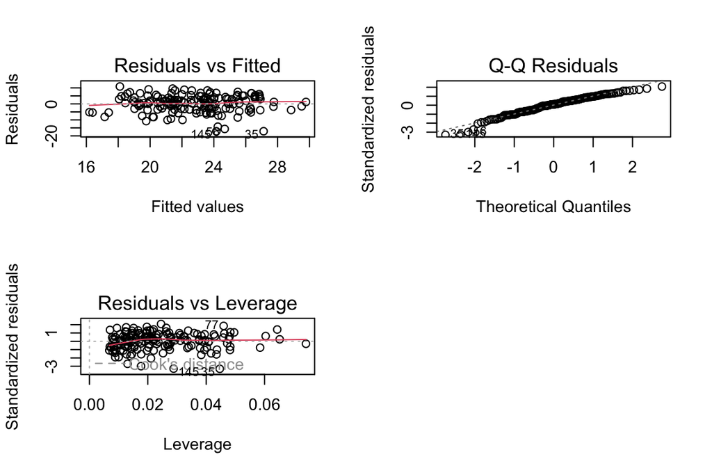

```r
# All four in the same plot
par(mfrow = c(2,2))

plot(model, which = c(1,2,5))
```

Above are three plots regarding residuals, where residual is a difference between the fitted and actual value.

The first plot (residuals vs fitted) is symmetrical and there is no correlation between residual and fitted value. Linear regression model is appropriate here.

The second plot shows quantiles against each other. This plot is linear too, so linear regression model is still valid.

The last plot uses standardized residuals with identical variance. The result is similar to plot 1.

# Chapter 3: Logistic regression

```r
date()
```

```
## [1] "Mon Nov 20 20:38:42 2023"
```

In the previous section we covered linear regression. Here we consider some cases where its use may be inappropriate. In particular, linear regression relies on the response variable being normally distributed. It might not even be continuous. In the case of a binary response variable we would prefer to use logistic regression

$log(\frac p {1-p}) = \alpha + \beta * X$

where $p$ is the probability of one outcome and $1-p$ probability of the other outcome, with $\beta$ and $X$ being coefficient and variable vectors for explanatory variables, which are multiplied element-wise.

Here $\frac p {1-p}$ are the odds for one outcome against another outcome (the usability of using odds instead of probabilities comes from fact that the fitted lines featuring the former are expected to be straight)

## Data analysis

The data set for analysis comes from studies about Portuguese students’ alcohol consumption:

http://www.archive.ics.uci.edu/dataset/320/student+performance

```r
library(dplyr)
alc <- read.table('data/alc_data.csv', sep=',', header = T)
glimpse(alc)
```

```
## Rows: 370
## Columns: 35
## $ school     <chr> "GP", "GP", "GP", "GP", "GP", "GP", "GP", "GP", "GP", "GP",…
## $ sex        <chr> "F", "F", "F", "F", "F", "M", "M", "F", "M", "M", "F", "F",…
## $ age        <int> 18, 17, 15, 15, 16, 16, 16, 17, 15, 15, 15, 15, 15, 15, 15,…
## $ address    <chr> "U", "U", "U", "U", "U", "U", "U", "U", "U", "U", "U", "U",…
## $ famsize    <chr> "GT3", "GT3", "LE3", "GT3", "GT3", "LE3", "LE3", "GT3", "LE…
## $ Pstatus    <chr> "A", "T", "T", "T", "T", "T", "T", "A", "A", "T", "T", "T",…
## $ Medu       <int> 4, 1, 1, 4, 3, 4, 2, 4, 3, 3, 4, 2, 4, 4, 2, 4, 4, 3, 3, 4,…
## $ Fedu       <int> 4, 1, 1, 2, 3, 3, 2, 4, 2, 4, 4, 1, 4, 3, 2, 4, 4, 3, 2, 3,…
## $ Mjob       <chr> "at_home", "at_home", "at_home", "health", "other", "servic…
## $ Fjob       <chr> "teacher", "other", "other", "services", "other", "other", …
## $ reason     <chr> "course", "course", "other", "home", "home", "reputation", …
## $ guardian   <chr> "mother", "father", "mother", "mother", "father", "mother",…
## $ traveltime <int> 2, 1, 1, 1, 1, 1, 1, 2, 1, 1, 1, 3, 1, 2, 1, 1, 1, 3, 1, 1,…
```

[output cut: 22 more lines]

The data has been combined from mathematics and Portuguese classes:

The data has a number of variables related to grading (G1, G2 and G3), absences, extra classes (*paid*) and previous failures (*failures*). It also has information about alcohol usage, including a boolean column for high alcohol usage (*high_use*). The rest are a variety of either numerical or categorical metadata columns.

The objective is to analyze the relation of alcohol consumption to the various categories. The hypothesis is that high alcohol consumption will lead to

- lower grades (especially *G3*)
- more *absences*

The student will also have spent less time on studying (*studytime*) and will not have had *paid* classes.

### Viewing the data

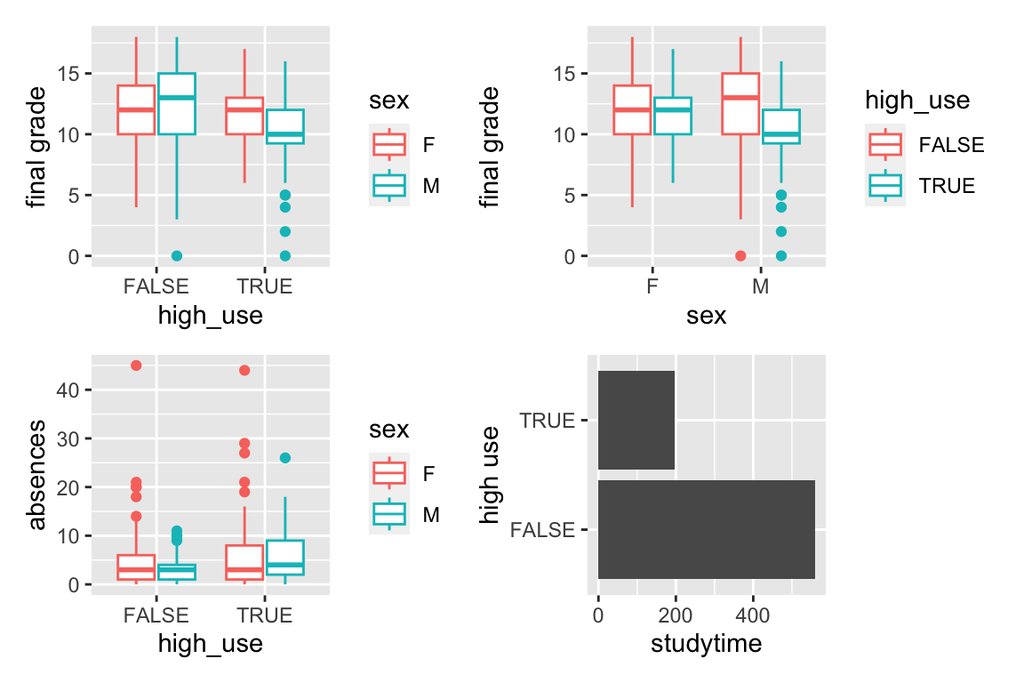

```r
library(tidyr); library(dplyr); library(ggplot2)

# install.packages("patchwork")
library(patchwork)

# initialize a plot of high_use and G3
g1 <- ggplot(alc, aes(x = high_use, y = G3, col = sex))
g1 <- g1 + geom_boxplot() + ylab("final grade")

g11 <- ggplot(alc, aes(x = sex, y = G3, col = high_use))
g11 <- g11 + geom_boxplot() + ylab("final grade")

g2 <- ggplot(alc, aes(x = high_use, y = absences, col = sex))
g2 <- g2 + geom_boxplot() + ylab("absences")

g3 <- ggplot(alc, aes(x = studytime, y = high_use))
g3 <- g3 + geom_col() + ylab("high use")

g4 <- ggplot(alc, aes(x = paid, y = high_use))
g4 <- g4 + geom_boxplot() + ylab("high use")

g1 + g11 + g2 + g3
```

Grades are lower and there are more absences with high alcohol usage, although the effect is more pronounced for men than women. Students with high alcohol consumption spent a lot less time on studying.

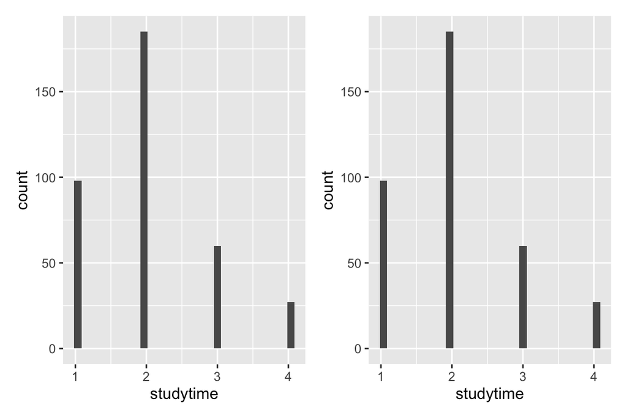

```r
gh <- ggplot(alc, aes(x = studytime))
gh <- gh + geom_histogram()

gh2 <- ggplot(alc, aes(x = studytime))
gh2 <- gh2 + geom_histogram()

gh + gh2
```

```r
table(high_use = alc$high_use, paid = alc$paid)
```

```
##         paid
## high_use  no yes
##    FALSE 140 119
##    TRUE   56  55
```

Those with low alcohol consumption used fewer paid classes, although the difference is not dramatic. My hypothesis was thus incorrect; it’s possible that students who use a lot of alcohol need the extra classes (perhaps to compensate for lack of study time?).

### Logistic regression model

```r
m <- glm(high_use ~ G3 + absences + studytime + paid, data = alc, family = "binomial")

# print out a summary of the model
summary(m)
```

```
##
## Call:
## glm(formula = high_use ~ G3 + absences + studytime + paid, family = "binomial",
##     data = alc)
##
## Coefficients:
##             Estimate Std. Error z value Pr(>|z|)
## (Intercept)  0.44301    0.51534   0.860 0.389984
## G3          -0.06369    0.03725  -1.710 0.087317 .
## absences     0.07688    0.02285   3.365 0.000766 ***
## studytime   -0.58041    0.16270  -3.567 0.000361 ***
## paidyes      0.40796    0.24619   1.657 0.097501 .
## ---
## Signif. codes:  0 '***' 0.001 '**' 0.01 '*' 0.05 '.' 0.1 ' ' 1
##
## (Dispersion parameter for binomial family taken to be 1)
##
##     Null deviance: 452.04  on 369  degrees of freedom
## Residual deviance: 414.63  on 365  degrees of freedom
## AIC: 424.63
##
## Number of Fisher Scoring iterations: 4
```

```r
# print out the coefficients of the model
coef(m)
```

```
## (Intercept)          G3    absences   studytime     paidyes
##  0.44300723 -0.06368689  0.07687909 -0.58041234  0.40795610
```

The low P-values for *absences* and *studytime* indicate high correlation. Surprisingly (?) grades do not.

```r
# compute odds ratios (OR)
OR <- coef(m) %>% exp

# compute confidence intervals (CI)
CI <- confint(m) %>% exp
# print out the odds ratios with their confidence intervals
cbind(OR, CI)
```

```
##                    OR     2.5 %   97.5 %
## (Intercept) 1.5573836 0.5663598 4.305756
## G3          0.9382987 0.8717178 1.009274
## absences    1.0799115 1.0350021 1.132305
## studytime   0.5596675 0.4024071 0.762707
## paidyes     1.5037411 0.9304002 2.446804
```

For grades (*G3*) and *paid* classes, 1.0 is within the confidence interval, thus there is no evidence that these variables are associated with high alcohol usage.

### Predictions

```r
m2 <- glm(high_use ~ absences + studytime, data = alc, family = "binomial")

probabilities <- predict(m2, type = "response")

# add probability
alc2 <- mutate(alc, probability = probabilities)

# use the probabilities to make a prediction of high_use
alc2 <- mutate(alc2, prediction = probability > 0.5)

table(high_use = alc2$high_use, prediction = alc2$prediction)
```

```
##         prediction
## high_use FALSE TRUE
##    FALSE   248   11
##    TRUE     93   18
```

```r
# tabulate the target variable versus the predictions
table(high_use = alc2$high_use, prediction = alc2$prediction) %>% prop.table() %>% addmargins()
```

```
##         prediction
## high_use      FALSE       TRUE        Sum
##    FALSE 0.67027027 0.02972973 0.70000000
##    TRUE  0.25135135 0.04864865 0.30000000
##    Sum   0.92162162 0.07837838 1.00000000
```

```r
# define a loss function (mean prediction error)
loss_func <- function(class, prob) {
  n_wrong <- abs(class - prob) > 0.5
  mean(n_wrong)
}

# call loss_func to compute the average number of wrong predictions in the (training) data
loss_func(class = alc2$high_use, prob = alc2$prediction)
```

```
## [1] 0.2810811
```

The probability of incorrect predictions is 28.1 %.

```r
table(high_use = alc2$high_use, high_absences = alc2$absences > 1) %>% prop.table() %>% addmargins()
```

```
##         high_absences
## high_use      FALSE       TRUE        Sum
##    FALSE 0.23513514 0.46486486 0.70000000
##    TRUE  0.07027027 0.22972973 0.30000000
##    Sum   0.30540541 0.69459459 1.00000000
```

```r
table(high_use = alc2$high_use, low_study = alc2$studytime < 2) %>% prop.table() %>% addmargins()
```

```
##         low_study
## high_use     FALSE      TRUE       Sum
##    FALSE 0.5486486 0.1513514 0.7000000
##    TRUE  0.1864865 0.1135135 0.3000000
##    Sum   0.7351351 0.2648649 1.0000000
```

```r
table(high_use = alc2$high_use, low_study_high_absence = alc2$studytime < 2 | alc2$absences > 1) %>% prop.table() %>% addmargins()
```

```
##         low_study_high_absence
## high_use      FALSE       TRUE        Sum
##    FALSE 0.19189189 0.50810811 0.70000000
##    TRUE  0.05405405 0.24594595 0.30000000
##    Sum   0.24594595 0.75405405 1.00000000
```

Guessing based on simple metrics such as low studytime and high absences it is not possible to get good predictions.

### Cross-validation

```r
# K-fold cross-validation
library(boot)
cv <- cv.glm(data = alc2, cost = loss_func, glmfit = m2, K = 10)

# average number of wrong predictions in the cross validation
cv$delta[1]
```

```
## [1] 0.2837838
```

Unexpectedly the cross-validation does not improve the previous result.

(more chapters to be added similarly as we proceed with the course!)